# main

## SDM274 Midterm Project

Check the requirements in `midterm_project.md`.

### Data Preprocessing

读取 `ai4i2020.csv`，其中共有10000条数据，每条数据有14个特征。其中前两个特征分别是索引和产品ID，对预测没有帮助，因此删除。`Machine failure` 是目标变量，取值为0或1分别代表未发生故障和发生故障。其后的五个特征是故障类型，本项目中不考虑这些特征。

剩余的六个特征分别是 `Type`、`Air temperature [K]`、`Process temperature [K]`、`Rotational speed [rpm]`、`Torque [Nm]`、`Tool wear [min]`。

先读取，丢弃无用信息，查看数据的基本信息。

```python
import warnings
warnings.filterwarnings("ignore", category = FutureWarning)

import numpy as np
import pandas as pd

data_csv = pd.read_csv('ai4i2020.csv')
data_csv.drop(columns = ['UDI', 'Product ID', 'TWF', 'HDF', 'PWF', 'OSF', 'RNF'], inplace = True)

data_csv.info()
data_csv.head()
```

```
<class 'pandas.core.frame.DataFrame'>
RangeIndex: 10000 entries, 0 to 9999
Data columns (total 7 columns):
 #   Column                   Non-Null Count  Dtype
---  ------                   --------------  -----
 0   Type                     10000 non-null  object
 1   Air temperature [K]      10000 non-null  float64
 2   Process temperature [K]  10000 non-null  float64
 3   Rotational speed [rpm]   10000 non-null  int64
 4   Torque [Nm]              10000 non-null  float64
 5   Tool wear [min]          10000 non-null  int64
 6   Machine failure          10000 non-null  int64
dtypes: float64(3), int64(3), object(1)
memory usage: 547.0+ KB
```

|  | Type | Air temperature [K] | Process temperature [K] | Rotational speed [rpm] | Torque [Nm] | Tool wear [min] | Machine failure |
| --- | --- | --- | --- | --- | --- | --- | --- |
| 0 | M | 298.1 | 308.6 | 1551 | 42.8 | 0 | 0 |
| 1 | L | 298.2 | 308.7 | 1408 | 46.3 | 3 | 0 |
| 2 | L | 298.1 | 308.5 | 1498 | 49.4 | 5 | 0 |
| 3 | L | 298.2 | 308.6 | 1433 | 39.5 | 7 | 0 |
| 4 | L | 298.2 | 308.7 | 1408 | 40.0 | 9 | 0 |

其中 `Type` 为三值离散特征，将其编码为数值。

```python
encoder_map = {value: idx for idx, value in enumerate(data_csv['Type'].unique())}
data_csv['Type'] = np.array([encoder_map[value] for value in data_csv['Type']])

data_csv.info()
data_csv.head()
```

```
<class 'pandas.core.frame.DataFrame'>
RangeIndex: 10000 entries, 0 to 9999
Data columns (total 7 columns):
 #   Column                   Non-Null Count  Dtype
---  ------                   --------------  -----
 0   Type                     10000 non-null  int64
 1   Air temperature [K]      10000 non-null  float64
 2   Process temperature [K]  10000 non-null  float64
 3   Rotational speed [rpm]   10000 non-null  int64
 4   Torque [Nm]              10000 non-null  float64
 5   Tool wear [min]          10000 non-null  int64
 6   Machine failure          10000 non-null  int64
dtypes: float64(3), int64(4)
memory usage: 547.0 KB
```

|  | Type | Air temperature [K] | Process temperature [K] | Rotational speed [rpm] | Torque [Nm] | Tool wear [min] | Machine failure |
| --- | --- | --- | --- | --- | --- | --- | --- |
| 0 | 0 | 298.1 | 308.6 | 1551 | 42.8 | 0 | 0 |
| 1 | 1 | 298.2 | 308.7 | 1408 | 46.3 | 3 | 0 |
| 2 | 1 | 298.1 | 308.5 | 1498 | 49.4 | 5 | 0 |
| 3 | 1 | 298.2 | 308.6 | 1433 | 39.5 | 7 | 0 |
| 4 | 1 | 298.2 | 308.7 | 1408 | 40.0 | 9 | 0 |

### Feature Engineering

针对特征进行一些处理，各操作效果与取舍过程详见后续 Comparison。

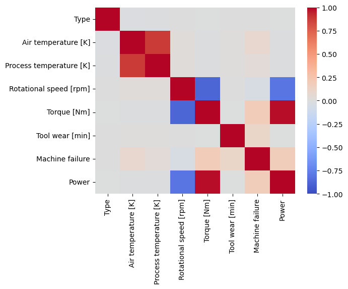

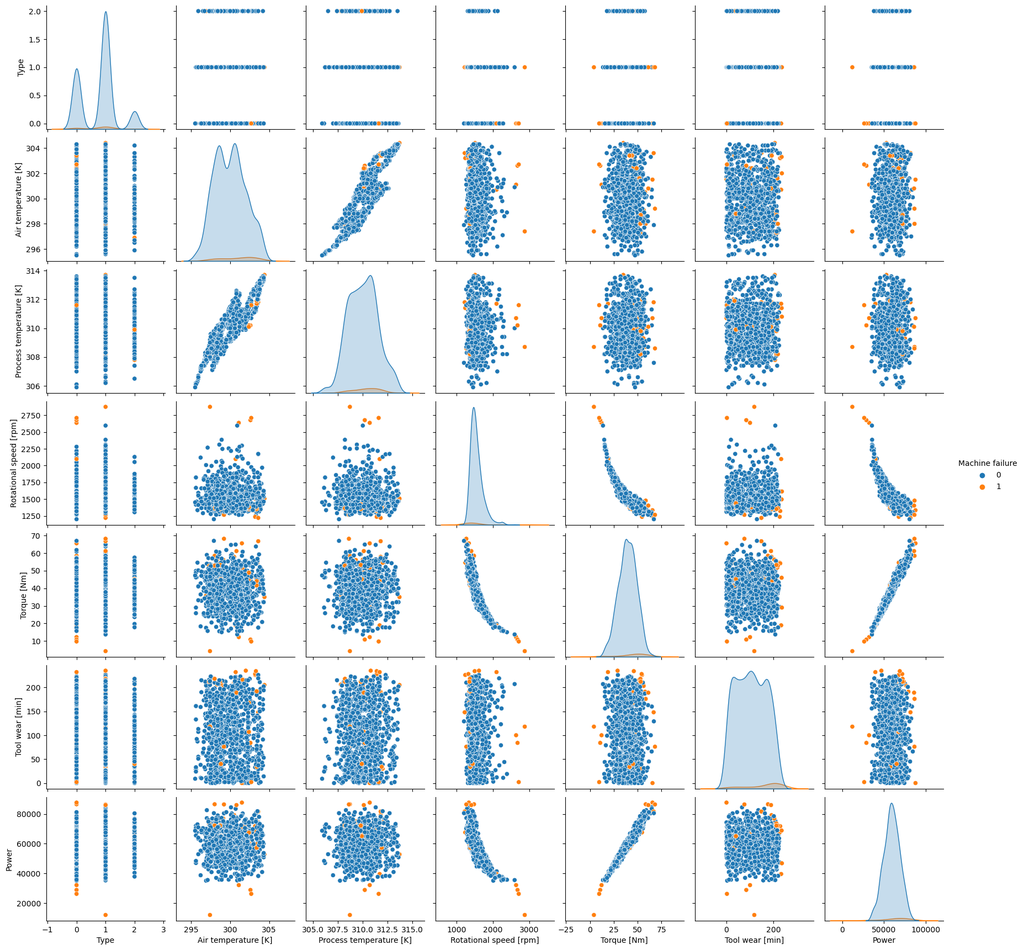

```python
import seaborn as sns
import matplotlib.pyplot as plt

""" 1. Drop Type """
# data_csv = data_csv[data_csv['Type'] != 'H']
# data_csv.drop(columns = ['Type'], inplace = True)

""" 2. PCA """
# from sklearn.decomposition import PCA
# from sklearn.preprocessing import StandardScaler
# selected_col = [
#     'Air temperature [K]', 'Process temperature [K]',
#     'Rotational speed [rpm]', 'Torque [Nm]'
# ]
# data_to_pca = data_csv[selected_col]
# scaler = StandardScaler()
# scaled_data = scaler.fit_transform(data_to_pca)
# pca = PCA(n_components=2)
# pca_result = pca.fit_transform(scaled_data)
# explained_variance_ratio = pca.explained_variance_ratio_
# data_csv['PCA_1'] = pca_result[:, 0]
# data_csv['PCA_2'] = pca_result[:, 1]
# data_csv.drop(columns = selected_col, inplace = True)
# label_col = data_csv.pop('Machine failure')
# data_csv['Machine failure'] = label_col

""" 3. Power """
data_csv['Power'] = data_csv[['Rotational speed [rpm]', 'Torque [Nm]']].product(axis = 1)

""" 4. Temperature Difference """
# data_csv['Temperature Difference'] = data_csv['Process temperature [K]'] - data_csv['Air temperature [K]']

""" 5. Strain """
# data_csv['Strain'] = data_csv[['Tool wear [min]', 'Torque [Nm]']].product(axis = 1)

""" 6. Remove Raw """
# data_csv.drop(columns = ['Process temperature [K]', 'Air temperature [K]', 'Tool wear [min]', 'Torque [Nm]'], inplace = True)

""" Result """
fN = len(data_csv.columns) - 1 # features number
sns.heatmap(data_csv.corr(), vmin = -1, vmax = 1, cmap = 'coolwarm')
sns.pairplot(data_csv.sample(frac = 0.1), hue = 'Machine failure')
plt.show()
```

将特征与标签分开。

```python
labels_np = data_csv['Machine failure'].to_numpy()

data_csv.drop(columns = ['Machine failure'], inplace = True)
features_np = data_csv.to_numpy()

data_np = np.c_[features_np, labels_np]

print(features_np.shape, labels_np.shape)
```

```
(10000, 7) (10000,)
```

调用`simple_ml`将其封装为`Dataset`类型，并划分为训练集和测试集。

同时，为了防止随机划分不平衡，我们编写一个新的函数对正负样本分别进行划分，然后合并。

```python
from simple_ml.data.dataset import *
from simple_ml.data.samples import *

dataset = Dataset(data = data_np, preprocess_func = label_split_for_single_output_dataset)
train_dataset_raw, test_dataset = split_train_and_test_dataset_with_equal_binary_label(dataset, 0.3, seed = 42)

print(np.sum(test_dataset.datas[1]) / (np.sum(train_dataset_raw.datas[1]) + np.sum(test_dataset.datas[1])))
```

```
0.3008849557522124
```

接下来，注意到数据集中的正负样本不平衡，出故障的样本数量极少，我们使用多种方法进行处理，例如随机过采样、随机欠采样、聚类欠采样等。

```python
from imblearn.over_sampling import SVMSMOTE

sampler = SVMSMOTE(random_state = 42)
features_bal, labels_bal = sampler.fit_resample(train_dataset_raw.datas[0], train_dataset_raw.datas[1])
train_dataset_bal = Dataset(data = np.c_[features_bal, labels_bal], preprocess_func = label_split_for_single_output_dataset)

# train_dataset_ru = balance_binary_labels_random_repeat(train_dataset_raw, label_pos = 1, label_neg = 0)
# train_dataset_rd = balance_binary_labels_random_remove(train_dataset_raw, label_pos = 1, label_neg = 0)
# train_dataset_cd = balance_binary_labels_cluster_downsample(train_dataset_raw, label_pos = 1, label_neg = 0)
# train_dataset_comb = balance_binary_labels_combined(train_dataset_raw, label_pos = 1, label_neg = 0, oversample_factor = 10)
# train_dataset_smote = balance_binary_labels_smote(train_dataset_raw, label_pos = 1, label_neg = 0, k_neighbors = 10)

# train_dataset_bal = train_dataset_raw

print(f'Positive samples: {int(np.sum(train_dataset_bal.datas[1]))} / {len(train_dataset_bal.datas[1])}')
```

```
Positive samples: 6762 / 13524
```

最后对训练集的特征进行 Mean Normalization，以便后续训练，并记录参数，同时应用到测试集上。

```python
from sklearn.preprocessing import StandardScaler, MinMaxScaler

scaler = StandardScaler()
train_dataset_bal.datas[0] = scaler.fit_transform(train_dataset_bal.datas[0])
test_dataset.datas[0] = scaler.transform(test_dataset.datas[0])

# features_means = np.mean(train_dataset.datas[0], axis = 0)
# features_stds = np.std(train_dataset.datas[0], axis = 0)

# def normalize_with_stored_params(features):
#     return (features - features_means) / features_stds

# train_dataset.datas[0] = normalize_with_stored_params(train_dataset.datas[0])
# test_dataset.datas[0] = normalize_with_stored_params(test_dataset.datas[0])
```

### Model Training and Testing

先导入 `simple_ml` 中的组件和一些需要的package。

```python
from simple_ml.model import *
from simple_ml.model.layers import *
from simple_ml.training.loss import *
from simple_ml.training.optimizer import *
from simple_ml.evaluation.criterion import *
```

#### Linear Regression

第一种是直接使用线性回归模型进行拟合。不过由于是二分类问题，因此我们需要给输出加上一个阈值，高于阈值的预测值为1，低于阈值的预测值为0。

线性回归模型的搭建直接使用我们的 `simple_ml` 中的一个 `Linear` 层即可，损失函数我们选取 `MSELoss`。

```
Epoch: 300 / 3000
Epoch: 600 / 3000
Epoch: 900 / 3000
Epoch: 1200 / 3000
Epoch: 1500 / 3000
Epoch: 1800 / 3000
Epoch: 2100 / 3000
Epoch: 2400 / 3000
Epoch: 2700 / 3000
Epoch: 3000 / 3000
```

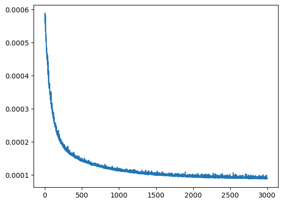

```
TP: 69, FP: 350, TN: 2549, FN: 33
Test: ACC = 0.8723758747084305, REC = 0.6764705882352942, PRE = 0.16467780429594273, F1 = 0.2648752399232246
```

```python
def linreg(optimizer, epoch_num, batch_size):
    model = Linear(fN, 1)
    loss_func = MSELoss()
    optimizer.params = model.params

    train_iter = DataIterator(train_dataset_bal, batch_size = batch_size, shuffle = True, cyclic = False)

    train_loss_buffer = []

    for epoch in range(epoch_num):
        train_loss = 0

        for batch, [features, labels] in enumerate(train_iter):
            prediction = model(Variable(features))
            loss = loss_func(prediction, labels)

            model.backward()
            optimizer.step()

            train_loss += loss

        train_loss /= len(train_dataset_bal)
        train_loss_buffer.append(train_loss)

        if (epoch + 1) % (epoch_num // 10) == 0:
            print(f'Epoch: {epoch + 1} / {epoch_num}')

    fig = plt.figure(1)
    plt.plot(np.arange(len(train_loss_buffer)), train_loss_buffer)
    plt.show()

    test_prediction = model(Variable(test_dataset.datas[0]))

    decision_threshold = 0.5
    [[TP, FN], [FP, TN]] = eval_binary_confusion_matrix(test_prediction, test_dataset.datas[1], decision_boundary = decision_threshold, label_pos = 1, label_neg = 0)
    print(f'TP: {TP}, FP: {FP}, TN: {TN}, FN: {FN}')
    test_accuracy = (TP + TN) / (TP + TN + FP + FN)
    test_recall = TP / (TP + FN)
    test_precision = TP / (TP + FP)
    test_f1_score = 2 * test_precision * test_recall / (test_precision + test_recall) if test_precision + test_recall > 0 else 0
    print(f'Test: ACC = {test_accuracy}, REC = {test_recall}, PRE = {test_precision}, F1 = {test_f1_score}')


optimizer = GD(None, lr = 0.0002)
linreg(optimizer, epoch_num = 3000, batch_size = len(train_dataset_bal) // 20)
```

#### Perceptron

第二种是使用 Perceptron 模型进行拟合，其前半部分与线性回归模型相同，使用的 Loss 函数则特殊一些，我们实现为 `BinaryPerceptronLoss`。

```
Epoch: 100 / 1000
Epoch: 200 / 1000
Epoch: 300 / 1000
Epoch: 400 / 1000
Epoch: 500 / 1000
Epoch: 600 / 1000
Epoch: 700 / 1000
Epoch: 800 / 1000
Epoch: 900 / 1000
Epoch: 1000 / 1000
```

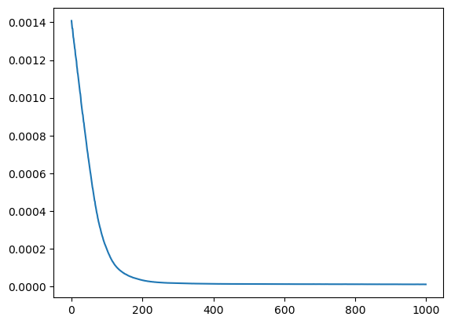

```
TP: 76, FP: 282, TN: 2617, FN: 26
Test: ACC = 0.8973675441519493, REC = 0.7450980392156863, PRE = 0.2122905027932961, F1 = 0.3304347826086957
```

```python
def perceptron(optimizer, epoch_num, batch_size):
    model = Linear(fN, 1)
    loss_func = BinaryPerceptronLoss()
    optimizer.params = model.params

    train_iter = DataIterator(train_dataset_bal, batch_size = batch_size, shuffle = True, cyclic = False)

    train_loss_buffer = []

    for epoch in range(epoch_num):
        train_loss = 0

        for batch, [features, labels] in enumerate(train_iter):
            prediction = model(Variable(features))
            loss = loss_func(prediction, labels)

            model.backward()
            optimizer.step()

            train_loss += loss

        train_loss /= len(train_dataset_bal)
        train_loss_buffer.append(train_loss)

        if (epoch + 1) % (epoch_num // 10) == 0:
            print(f'Epoch: {epoch + 1} / {epoch_num}')

    fig = plt.figure(1)
    plt.plot(np.arange(len(train_loss_buffer)), train_loss_buffer)
    plt.show()

    test_prediction = model(Variable(test_dataset.datas[0]))
    [[TP, FN], [FP, TN]] = eval_binary_confusion_matrix(test_prediction, test_dataset.datas[1], decision_boundary = 0, label_pos = 1, label_neg = 0)
    print(f'TP: {TP}, FP: {FP}, TN: {TN}, FN: {FN}') # TODO
    test_accuracy = (TP + TN) / (TP + TN + FP + FN)
    test_recall = TP / (TP + FN)
    test_precision = TP / (TP + FP)
    test_f1_score = 2 * test_precision * test_recall / (test_precision + test_recall) if test_precision + test_recall > 0 else 0
    print(f'Test: ACC = {test_accuracy}, REC = {test_recall}, PRE = {test_precision}, F1 = {test_f1_score}')


optimizer = GD(None, lr = 0.02)
perceptron(optimizer, epoch_num = 1000, batch_size = len(train_dataset_bal) // 100)
```

#### Logistic Regression

第三种是使用 Logistic Regression 模型进行拟合，其前半部分与线性回归模型相同，之后使用 `Sigmoid` 激活函数，Loss 函数我们选取 `CrossEntropyLoss`。

```
Epoch: 300 / 3000
Epoch: 600 / 3000
Epoch: 900 / 3000
Epoch: 1200 / 3000
Epoch: 1500 / 3000
Epoch: 1800 / 3000
Epoch: 2100 / 3000
Epoch: 2400 / 3000
Epoch: 2700 / 3000
Epoch: 3000 / 3000
```

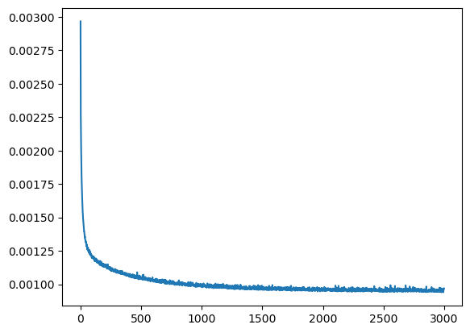

```
TP: 76, FP: 277, TN: 2622, FN: 26
Test: ACC = 0.8990336554481839, REC = 0.7450980392156863, PRE = 0.21529745042492918, F1 = 0.33406593406593404
```

```python
def logreg(optimizer, epoch_num, batch_size):
    model = Sequential([
        Linear(fN, 1),
        Sigmoid()
    ])
    loss_func = CrossEntropyLoss()
    optimizer.params = model.params

    train_iter = DataIterator(train_dataset_bal, batch_size = batch_size, shuffle = True, cyclic = False)

    train_loss_buffer = []

    for epoch in range(epoch_num):
        train_loss = 0

        for batch, [features, labels] in enumerate(train_iter):
            prediction = model(Variable(features))
            loss = loss_func(prediction, labels)

            model.backward()
            optimizer.step()

            train_loss += loss

        train_loss /= len(train_dataset_bal)
        train_loss_buffer.append(train_loss)

        if (epoch + 1) % (epoch_num // 10) == 0:
            print(f'Epoch: {epoch + 1} / {epoch_num}')

    fig = plt.figure(1)
    plt.plot(np.arange(len(train_loss_buffer)), train_loss_buffer)
    plt.show()

    test_prediction = model(Variable(test_dataset.datas[0]))
    [[TP, FN], [FP, TN]] = eval_binary_confusion_matrix(test_prediction, test_dataset.datas[1], decision_boundary = 0.5, label_pos = 1, label_neg = 0)
    print(f'TP: {TP}, FP: {FP}, TN: {TN}, FN: {FN}')
    test_accuracy = (TP + TN) / (TP + TN + FP + FN)
    test_recall = TP / (TP + FN)
    test_precision = TP / (TP + FP)
    test_f1_score = 2 * test_precision * test_recall / (test_precision + test_recall) if test_precision + test_recall > 0 else 0
    print(f'Test: ACC = {test_accuracy}, REC = {test_recall}, PRE = {test_precision}, F1 = {test_f1_score}')


optimizer = GD(None, lr = 0.03)
logreg(optimizer, epoch_num = 3000, batch_size = len(train_dataset_bal) // 50)
```

#### MLP

第四种是使用MLP。

```
Epoch: 300 / 3000
Epoch: 600 / 3000
Epoch: 900 / 3000
Epoch: 1200 / 3000
Epoch: 1500 / 3000
Epoch: 1800 / 3000
Epoch: 2100 / 3000
Epoch: 2400 / 3000
Epoch: 2700 / 3000
Epoch: 3000 / 3000
```

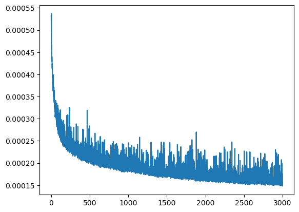

```
TP: 84, FP: 242, TN: 2657, FN: 18
Test: ACC = 0.9133622125958014, REC = 0.8235294117647058, PRE = 0.25766871165644173, F1 = 0.3925233644859813
```

```python
def mlp(model, loss_func, optimizer, epoch_num, batch_size):
    train_iter = DataIterator(train_dataset_bal, batch_size = batch_size, shuffle = True, cyclic = False)

    train_loss_buffer = []

    for epoch in range(epoch_num):
        train_loss = 0

        for batch, [features, labels] in enumerate(train_iter):
            prediction = model(Variable(features))
            loss = loss_func(prediction, labels)

            model.backward()
            optimizer.step()

            train_loss += loss

        train_loss /= len(train_dataset_bal)
        train_loss_buffer.append(train_loss)

        if (epoch + 1) % (epoch_num // 10) == 0:
            print(f'Epoch: {epoch + 1} / {epoch_num}')

    fig = plt.figure(1)
    plt.plot(np.arange(len(train_loss_buffer)), train_loss_buffer)
    plt.show()

    test_prediction = model(Variable(test_dataset.datas[0]))
    [[TP, FN], [FP, TN]] = eval_binary_confusion_matrix(test_prediction, test_dataset.datas[1], decision_boundary = 0.5, label_pos = 1, label_neg = 0)
    print(f'TP: {TP}, FP: {FP}, TN: {TN}, FN: {FN}')
    test_accuracy = (TP + TN) / (TP + TN + FP + FN)
    test_recall = TP / (TP + FN)
    test_precision = TP / (TP + FP)
    test_f1_score = 2 * test_precision * test_recall / (test_precision + test_recall) if test_precision + test_recall > 0 else 0
    print(f'Test: ACC = {test_accuracy}, REC = {test_recall}, PRE = {test_precision}, F1 = {test_f1_score}')


model = Sequential([
    Linear(fN, 100),
    ReLU(),
    Linear(100, 1),
    Sigmoid()
])
loss_func = CrossEntropyLoss()
optimizer = GD(model.params, lr = 0.01)
mlp(model, loss_func, optimizer, epoch_num = 3000, batch_size = len(train_dataset_bal) // 10)
```

### Comparison

前面分别实现了 Linear Regression，Perceptron，Logistic Regression 和 MLP，并进行了简单的测试（细致的调整在接下来进行）。

简单测试中反映出的情况是，线性回归、感知器模型以及逻辑回归所得到的 Test F1 Score 相差不大，都在 0.3 略少一些的程度。其中线性回归结果稳定但整体效果稍低于其他模型；感知器模型的损失函数由于非凸，训练结果有时效果不佳，多次尝试后较好的结果和其他相差不多。

MLP 只进行了简单的测试，单隐藏层（100 个神经元），效果较明显优于其他模型，且可以观察到还有提升的空间，后续进行超参数调整。

总体来看，由于数据标签不均衡，所以 Accuracy 没有参考价值。F1 由 Recall 和 Precision 计算得来，其中都是 Recall 偏高而 Precision 偏低，也就是经常将 0 错判为 1。

此外，以上结果也依赖之前对**训练集数据**进行的一系列变换、归一化、上采样等操作：

1. 根据原数据相关性热图，使用 PCA 对相关性较高的两组特征进行合并，不过效果不好，注释了；
2. 在添加了一项 Power = Rotational speed * Torque 特征之后，模型训练后的 Test F1 Score 整体略有提升，来到了 0.3 以上，以感知器模型提升最为明显。参考这一点，我们再加入其他特征项进行尝试；
3. 添加 Temperature Difference = Process temperature - Air temperature 和 Strain = Tool wear * Torque 后效果没有明显提升，而训练耗时显著提高；
4. 只保留计算得到的新特征，去掉除转速以外的原特征后效果似乎有所降低；
5. 最终修改回仅添加 Power 的情况。

最终除线性回归都在 0.33 以上，接下来对 MLP 进行超参调节。

### Hyperparameter Tuning

测试不同网络结构的 MLP。

```
Epoch: 1000 / 10000
Epoch: 2000 / 10000
Epoch: 3000 / 10000
Epoch: 4000 / 10000
Epoch: 5000 / 10000
Epoch: 6000 / 10000
Epoch: 7000 / 10000
Epoch: 8000 / 10000
Epoch: 9000 / 10000
Epoch: 10000 / 10000
```

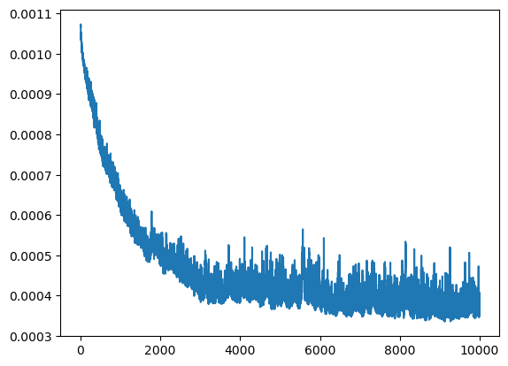

```
TP: 79, FP: 225, TN: 2674, FN: 23
Test: ACC = 0.9173608797067644, REC = 0.7745098039215687, PRE = 0.2598684210526316, F1 = 0.3891625615763547
```

```python
model = Sequential([
    Linear(fN, 5),
    ReLU(),
    Linear(5, 1),
    Sigmoid()
])
loss_func = CrossEntropyLoss()
optimizer = GD(model.params, lr = 0.01)
mlp(model, loss_func, optimizer, epoch_num = 10000, batch_size = len(train_dataset_bal) // 20)
```

```
Epoch: 500 / 5000
Epoch: 1000 / 5000
Epoch: 1500 / 5000
Epoch: 2000 / 5000
Epoch: 2500 / 5000
Epoch: 3000 / 5000
Epoch: 3500 / 5000
Epoch: 4000 / 5000
Epoch: 4500 / 5000
Epoch: 5000 / 5000
```

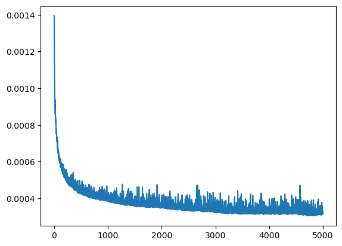

```
TP: 84, FP: 245, TN: 2654, FN: 18
Test: ACC = 0.9123625458180606, REC = 0.8235294117647058, PRE = 0.2553191489361702, F1 = 0.38979118329466356
```

```python
model = Sequential([
    Linear(fN, 25),
    ReLU(),
    Linear(25, 1),
    Sigmoid()
])
loss_func = CrossEntropyLoss()
optimizer = GD(model.params, lr = 0.01)
mlp(model, loss_func, optimizer, epoch_num = 5000, batch_size = len(train_dataset_bal) // 20)
```

```
Epoch: 2000 / 20000
Epoch: 4000 / 20000
Epoch: 6000 / 20000
Epoch: 8000 / 20000
Epoch: 10000 / 20000
Epoch: 12000 / 20000
Epoch: 14000 / 20000
Epoch: 16000 / 20000
Epoch: 18000 / 20000
Epoch: 20000 / 20000
```

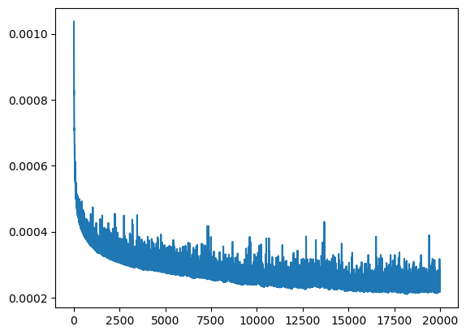

```
TP: 83, FP: 194, TN: 2705, FN: 19
Test: ACC = 0.9290236587804065, REC = 0.8137254901960784, PRE = 0.2996389891696751, F1 = 0.4379947229551451
```

```python
model = Sequential([
    Linear(fN, 50),
    ReLU(),
    Linear(50, 1),
    Sigmoid()
])
loss_func = CrossEntropyLoss()
optimizer = GD(model.params, lr = 0.01)
mlp(model, loss_func, optimizer, epoch_num = 20000, batch_size = len(train_dataset_bal) // 20)
```

```
Epoch: 500 / 5000
Epoch: 1000 / 5000
Epoch: 1500 / 5000
Epoch: 2000 / 5000
Epoch: 2500 / 5000
Epoch: 3000 / 5000
Epoch: 3500 / 5000
Epoch: 4000 / 5000
Epoch: 4500 / 5000
Epoch: 5000 / 5000
```

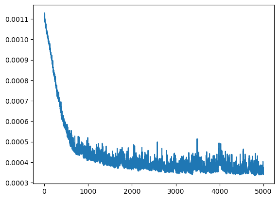

```
TP: 80, FP: 253, TN: 2646, FN: 22
Test: ACC = 0.9083638787070977, REC = 0.7843137254901961, PRE = 0.24024024024024024, F1 = 0.367816091954023
```

```python
model = Sequential([
    Linear(fN, 10),
    Tanh(),
    Linear(10, 10),
    Tanh(),
    Linear(10, 1),
    Sigmoid()
])
loss_func = CrossEntropyLoss()
optimizer = GD(model.params, lr = 0.01)
mlp(model, loss_func, optimizer, epoch_num = 5000, batch_size = len(train_dataset_bal) // 20)
```

```
Epoch: 4000 / 40000
Epoch: 8000 / 40000
Epoch: 12000 / 40000
Epoch: 16000 / 40000
Epoch: 20000 / 40000
Epoch: 24000 / 40000
Epoch: 28000 / 40000
Epoch: 32000 / 40000
Epoch: 36000 / 40000
Epoch: 40000 / 40000
```

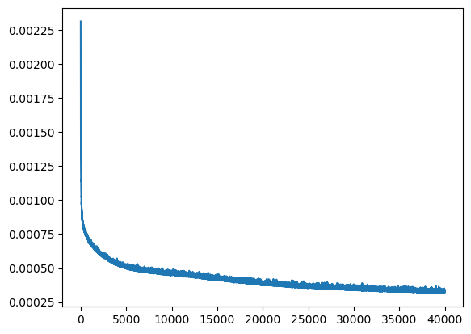

```
TP: 80, FP: 162, TN: 2737, FN: 22
Test: ACC = 0.9386871042985672, REC = 0.7843137254901961, PRE = 0.3305785123966942, F1 = 0.46511627906976744
```

```python
model = Sequential([
    Linear(fN, 20),
    Tanh(),
    Linear(20, 20),
    Tanh(),
    Linear(20, 1),
    Sigmoid()
])
loss_func = CrossEntropyLoss()
optimizer = GD(model.params, lr = 0.01)
mlp(model, loss_func, optimizer, epoch_num = 40000, batch_size = len(train_dataset_bal) // 30)
```

```
Epoch: 2000 / 20000
Epoch: 4000 / 20000
Epoch: 6000 / 20000
Epoch: 8000 / 20000
Epoch: 10000 / 20000
Epoch: 12000 / 20000
Epoch: 14000 / 20000
Epoch: 16000 / 20000
Epoch: 18000 / 20000
Epoch: 20000 / 20000
```

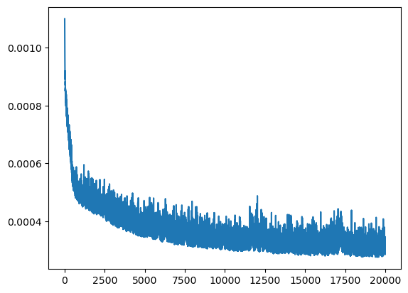

```
TP: 81, FP: 248, TN: 2651, FN: 21
Test: ACC = 0.9103632122625791, REC = 0.7941176470588235, PRE = 0.24620060790273557, F1 = 0.37587006960556846
```

```python
model = Sequential([
    Linear(fN, 10),
    Tanh(),
    Linear(10, 10),
    Tanh(),
    Linear(10, 10),
    Tanh(),
    Linear(10, 1),
    Sigmoid()
])
loss_func = CrossEntropyLoss()
optimizer = GD(model.params, lr = 0.01)
mlp(model, loss_func, optimizer, epoch_num = 20000, batch_size = len(train_dataset_bal) // 20)
```

选取如上结构的模型，分别多次训练得到较合适的 epoch_num 和 batch_size，发现其中两个隐藏层各 20 个神经元的模型训练过程稳定，效果较好，尝试提供一个更长的训练时间：

```
Epoch: 8000 / 80000
Epoch: 16000 / 80000
Epoch: 24000 / 80000
Epoch: 32000 / 80000
Epoch: 40000 / 80000
Epoch: 48000 / 80000
Epoch: 56000 / 80000
Epoch: 64000 / 80000
Epoch: 72000 / 80000
Epoch: 80000 / 80000
```

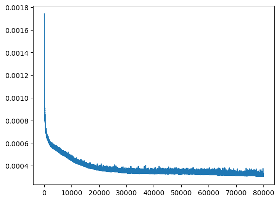

```
TP: 80, FP: 184, TN: 2715, FN: 22
Test: ACC = 0.931356214595135, REC = 0.7843137254901961, PRE = 0.30303030303030304, F1 = 0.4371584699453552
```

```python
model = Sequential([
    Linear(fN, 20),
    Tanh(),
    Linear(20, 20),
    Tanh(),
    Linear(20, 1),
    Sigmoid()
])
loss_func = CrossEntropyLoss()
optimizer = GD(model.params, lr = 0.01)
mlp(model, loss_func, optimizer, epoch_num = 80000, batch_size = len(train_dataset_bal) // 30)
```

```
Epoch: 8000 / 80000
Epoch: 16000 / 80000
Epoch: 24000 / 80000
Epoch: 32000 / 80000
Epoch: 40000 / 80000
Epoch: 48000 / 80000
Epoch: 56000 / 80000
Epoch: 64000 / 80000
Epoch: 72000 / 80000
Epoch: 80000 / 80000
```

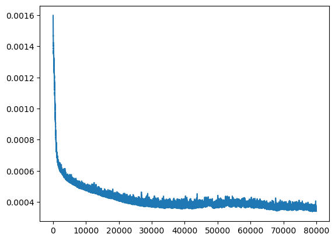

```
TP: 81, FP: 198, TN: 2701, FN: 21
Test: ACC = 0.9270243252249251, REC = 0.7941176470588235, PRE = 0.2903225806451613, F1 = 0.4251968503937008
```

```python
model = Sequential([
    Linear(fN, 20),
    Tanh(),
    Linear(20, 5),
    Tanh(),
    Linear(5, 1),
    Sigmoid()
])
loss_func = CrossEntropyLoss()
optimizer = GD(model.params, lr = 0.01)
mlp(model, loss_func, optimizer, epoch_num = 80000, batch_size = len(train_dataset_bal) // 30)
```